# FigureYa235scDEG

**Author(s)**: Xiao Gu  
**Reviewer(s)**: Ying Ge, Hui Huang  
**Date**: 2025-12-03

## 1 Academic Citation

If you use this code in your work or research, we kindly request that you cite our publication:

Xiaofan Lu, et al. (2025). FigureYa: A Standardized Visualization Framework for Enhancing Biomedical Data Interpretation and Research Efficiency. iMetaMed. https://doi.org/10.1002/imm3.70005

## 2 需求描述 Requirement Description

单细胞测序分不同的cluster，然后在每个cluster上做DEGs的点图，最好是log2FC为负的标蓝。然后自定义显示想要的点。 输入数据用seurat用的PBMC那个测试数据吧

Single-cell sequencing is divided into different clusters, and then a dot plot of DEGs is made on each cluster, preferably with a negative log2FC in blue. Then customize the display of the desired points. The input data will be the PBMC test data for the seurat

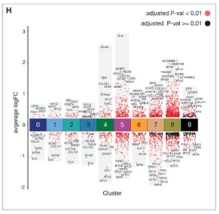

From https://www.sciencedirect.com/science/article/pii/S0092867419312826?via%3Dihub

Figure 2. Global Spatiotemporal Analysis of Three Cardiac Developmental Stages (H) Differential gene expression analysis showing up- and down-regulated genes across all ten clusters. An adjusted p value < 0.01 is indicated in red, while an adjusted p value R 0.01 is indicated in black.

## 3 应用场景 Application Scenarios

分类展示各cluster的marker gene表达趋势变化的分布情况。

可以像原文那样标注显著上调或下调表达的基因名，或者标注参与某一通路的基因名。

The distribution of marker gene expression trends in each cluster is displayed by category.

Gene names that are significantly up- or down-regulated, or gene names involved in a pathway, can be labeled as in the original text.

## 4 环境设置 Environment settings

```r
source("install_dependencies.R")
```

[output not shown]

[output not shown]

[output not shown]

```r
library(dplyr) #数据处理 Data processing
library(Seurat) # 单细胞数据处理 Single-cell data processing
```

```r
library(patchwork) #拼图 Plotting
library(reshape2) #数据处理 Data processing
library(RColorBrewer) #颜色 Color
library(ggplot2) #绘图 Plotting
library(ggrepel)  # 标注文本 Annotation text
library(magrittr) #数据处理 Data processing

Sys.setenv(LANGUAGE = "en") #显示英文报错信息 # error messages are displayed in English
options(stringsAsFactors = FALSE) #禁止chr转成factor # chr is not allowed to be converted to factor
```

## 5 输入文件 Input files

这部分与“FigureYa224scMarker”相同

以Seurat官网PBMC数据为例，跟FigureYa111markerGene和FigureYa160scGSVA用的是同一套数据，出自不同作者之手，可相互参考。

下载https://cf.10xgenomics.com/samples/cell/pbmc3k/pbmc3k_filtered_gene_bc_matrices.tar.gz，解压到当前文件夹。

预处理过程参考https://satijalab.org/seurat/v3.2/pbmc3k_tutorial.html

This part is the same as “FigureYa224scMarker”.

Taking the PBMC data on the official website of Seurat as an example, it uses the same set of data as FigureYa111markerGene and FigureYa160scGSVA, which are from different authors and can be cross-referenced.

Download the https://cf.10xgenomics.com/samples/cell/pbmc3k/pbmc3k_filtered_gene_bc_matrices.tar.gz and extract it to the current folder.

Refer to https://satijalab.org/seurat/v3.2/pbmc3k_tutorial.html for the pretreatment process

```r
untar("pbmc3k_filtered_gene_bc_matrices.tar.gz", exdir = ".")
# Load the PBMC dataset
pbmc.data <- Read10X(data.dir = "filtered_gene_bc_matrices/hg19/")
# Initialize the Seurat object with the raw (non-normalized data).
pbmc <- CreateSeuratObject(counts = pbmc.data, project = "pbmc3k", min.cells = 3, min.features = 200)
pbmc
```

```
## An object of class Seurat
## 13714 features across 2700 samples within 1 assay
## Active assay: RNA (13714 features, 0 variable features)
##  1 layer present: counts
```

## 6 预处理 Preprocessing

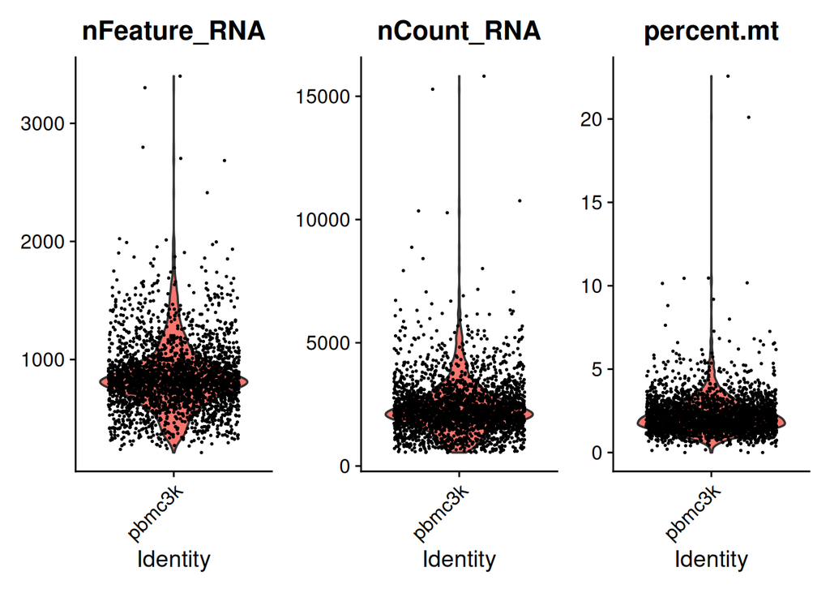

```r
# 进行QC
# 计算mitochondria基因比例
# Perform QC
# Calculate the mitochondria gene ratio
pbmc[["percent.mt"]] <- PercentageFeatureSet(pbmc, pattern = "^MT-")

# Visualize QC metrics as a violin plot
VlnPlot(pbmc, features = c("nFeature_RNA", "nCount_RNA", "percent.mt"), ncol = 3)
```

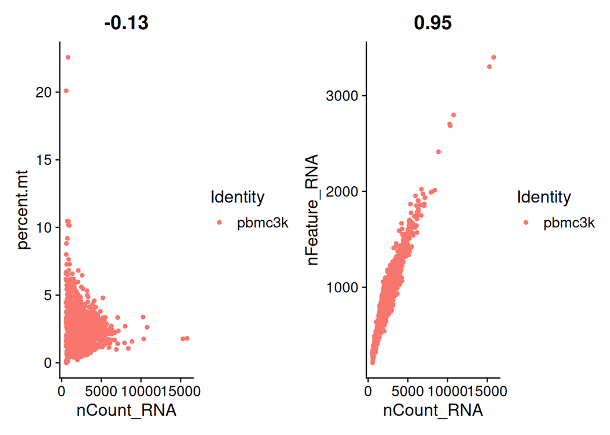

```r
plot1 <- FeatureScatter(pbmc, feature1 = "nCount_RNA", feature2 = "percent.mt")
plot2 <- FeatureScatter(pbmc, feature1 = "nCount_RNA", feature2 = "nFeature_RNA")
plot1 + plot2
```

```r
# Normalizing the data
pbmc <- NormalizeData(pbmc, normalization.method = "LogNormalize", scale.factor = 10000)
```

```
## Normalizing layer: counts
```

```r
#Identification of highly variable features
pbmc <- FindVariableFeatures(pbmc, selection.method = "vst", nfeatures = 2000)
```

```
## Finding variable features for layer counts
```

```r
# Identify the 10 most highly variable genes
# top10 <- head(VariableFeatures(pbmc), 10)
# plot variable features with and without labels
# plot1 <- VariableFeaturePlot(pbmc)
# plot2 <- LabelPoints(plot = plot1, points = top10, repel = TRUE)
# plot1 + plot2

# Scale the data
all.genes <- rownames(pbmc)
pbmc <- ScaleData(pbmc, features = all.genes)
# Perform linear dimensional reduction
pbmc <- RunPCA(pbmc, features = VariableFeatures(object = pbmc))
```

```
## PC_ 1
## Positive:  MALAT1, LTB, IL32, CD2, ACAP1, STK17A, CTSW, CD247, CCL5, GIMAP5
##     AQP3, GZMA, CST7, TRAF3IP3, MAL, HOPX, ITM2A, GZMK, MYC, BEX2
##     GIMAP7, ETS1, LDLRAP1, ZAP70, LYAR, RIC3, TNFAIP8, KLRG1, SAMD3, NKG7
## Negative:  CST3, TYROBP, LST1, AIF1, FTL, FCN1, LYZ, FTH1, S100A9, FCER1G
##     TYMP, CFD, LGALS1, CTSS, S100A8, SERPINA1, LGALS2, SPI1, IFITM3, PSAP
##     CFP, SAT1, IFI30, COTL1, S100A11, NPC2, LGALS3, GSTP1, PYCARD, NCF2
## PC_ 2
## Positive:  CD79A, MS4A1, TCL1A, HLA-DQA1, HLA-DRA, HLA-DQB1, LINC00926, CD79B, HLA-DRB1, CD74
##     HLA-DPB1, HLA-DMA, HLA-DQA2, HLA-DRB5, HLA-DPA1, HLA-DMB, FCRLA, HVCN1, LTB, BLNK
##     KIAA0125, P2RX5, IRF8, IGLL5, SWAP70, ARHGAP24, SMIM14, PPP1R14A, FCRL2, C16orf74
## Negative:  NKG7, PRF1, CST7, GZMA, GZMB, FGFBP2, CTSW, GNLY, GZMH, SPON2
##     CCL4, FCGR3A, CCL5, CD247, XCL2, CLIC3, AKR1C3, SRGN, HOPX, CTSC
##     TTC38, S100A4, ANXA1, IL32, IGFBP7, ID2, ACTB, XCL1, APOBEC3G, SAMD3
## PC_ 3
## Positive:  HLA-DQA1, CD79A, CD79B, HLA-DQB1, HLA-DPB1, CD74, HLA-DPA1, MS4A1, HLA-DRB1, HLA-DRB5
##     HLA-DRA, HLA-DQA2, TCL1A, LINC00926, HLA-DMB, HLA-DMA, HVCN1, FCRLA, IRF8, BLNK
##     KIAA0125, SMIM14, PLD4, IGLL5, P2RX5, TMSB10, SWAP70, LAT2, MALAT1, IGJ
## Negative:  PPBP, PF4, SDPR, SPARC, GNG11, NRGN, GP9, RGS18, TUBB1, CLU
##     HIST1H2AC, AP001189.4, ITGA2B, CD9, TMEM40, CA2, PTCRA, ACRBP, MMD, TREML1
##     NGFRAP1, F13A1, RUFY1, SEPT5, MPP1, CMTM5, TSC22D1, MYL9, RP11-367G6.3, GP1BA
## PC_ 4
## Positive:  HLA-DQA1, CD79A, CD79B, HIST1H2AC, HLA-DQB1, PF4, MS4A1, SDPR, CD74, PPBP
##     HLA-DPB1, GNG11, HLA-DQA2, SPARC, HLA-DRB1, HLA-DPA1, GP9, TCL1A, HLA-DRA, LINC00926
##     NRGN, RGS18, HLA-DRB5, PTCRA, CD9, AP001189.4, CA2, CLU, TUBB1, ITGA2B
## Negative:  VIM, S100A8, S100A6, S100A4, S100A9, TMSB10, IL32, GIMAP7, LGALS2, S100A10
##     RBP7, FCN1, MAL, LYZ, S100A12, MS4A6A, CD2, FYB, S100A11, FOLR3
##     GIMAP4, AQP3, ANXA1, AIF1, MALAT1, GIMAP5, IL8, IFI6, TRABD2A, TMSB4X
## PC_ 5
## Positive:  GZMB, FGFBP2, NKG7, GNLY, PRF1, CCL4, CST7, SPON2, GZMA, CLIC3
##     GZMH, XCL2, CTSW, TTC38, AKR1C3, CCL5, IGFBP7, XCL1, CCL3, S100A8
##     TYROBP, HOPX, CD160, HAVCR2, S100A9, FCER1G, PTGDR, LGALS2, RBP7, S100A12
## Negative:  LTB, VIM, AQP3, PPA1, MAL, KIAA0101, CD2, CYTIP, CORO1B, FYB
##     IL32, TRADD, ANXA5, TUBA1B, HN1, TYMS, PTGES3, ITM2A, COTL1, GPR183
##     TNFAIP8, ACTG1, TRAF3IP3, ATP5C1, GIMAP4, ZWINT, PRDX1, LDLRAP1, ABRACL, NGFRAP1
```

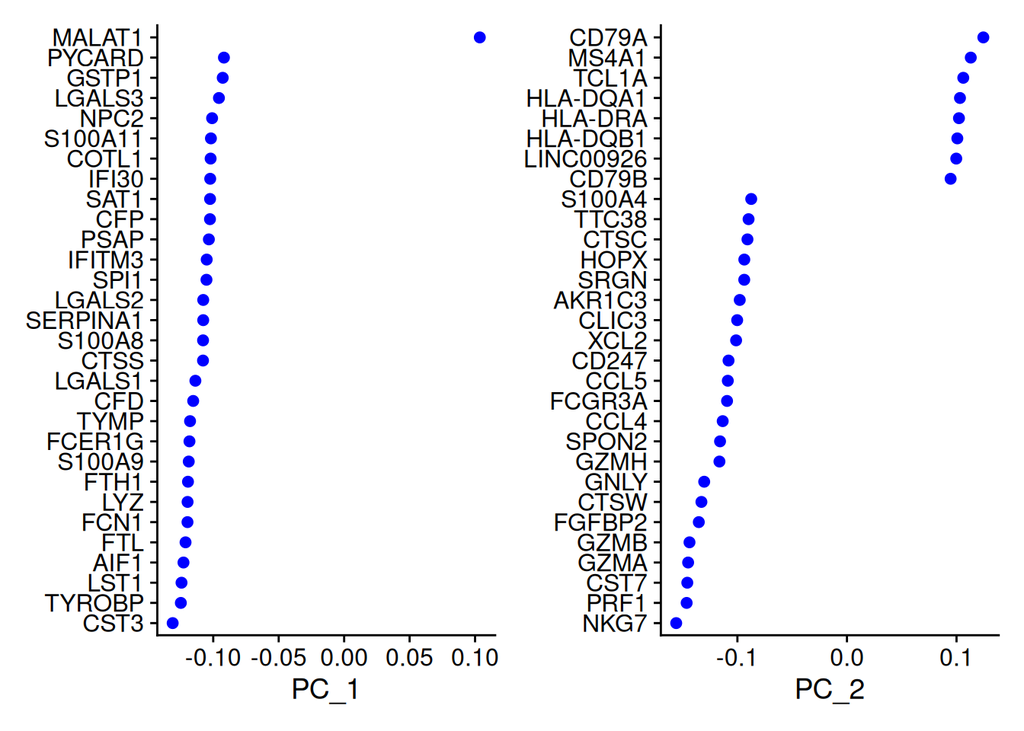

```r
#print(pbmc[["pca"]], dims = 1:5, nfeatures = 5)
VizDimLoadings(pbmc, dims = 1:2, reduction = "pca")
```

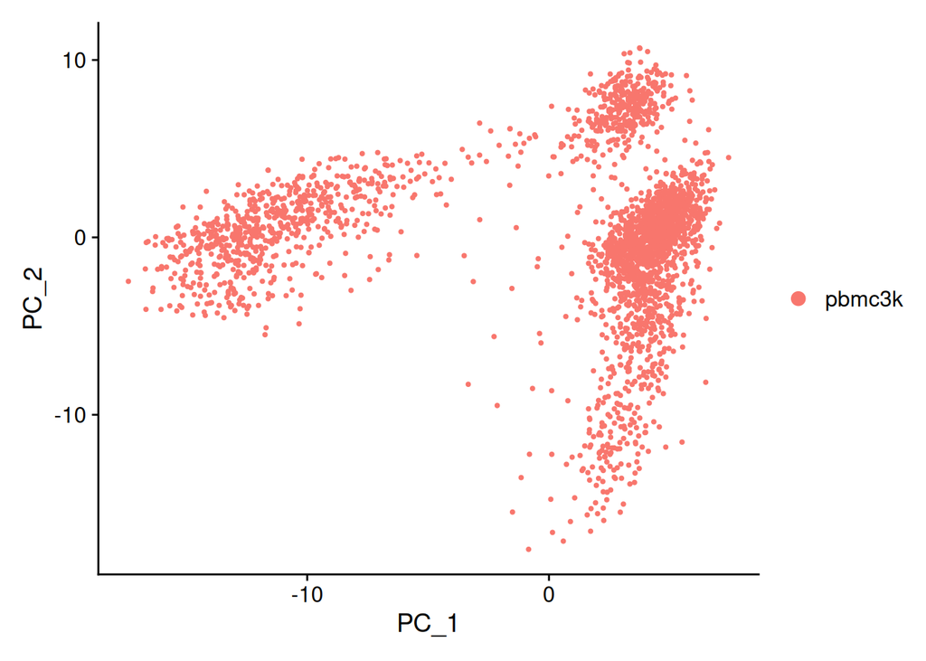

```r
DimPlot(pbmc, reduction = "pca")
```

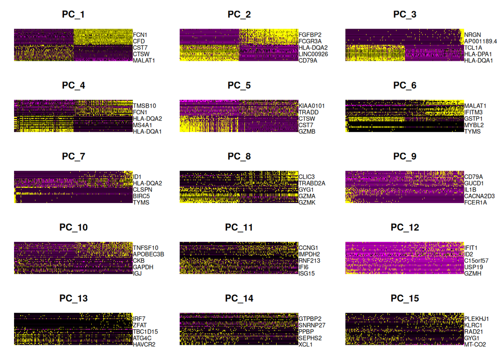

```r
DimHeatmap(pbmc, dims = 1:15, cells = 500, balanced = TRUE)
```

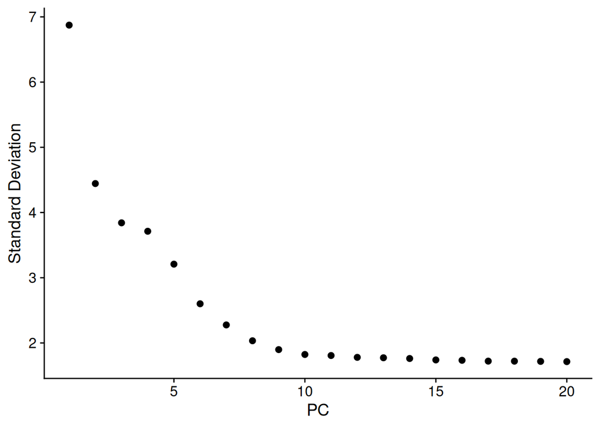

```r
# NOTE: This process can take a long time for big datasets, comment out for expediency. More
# approximate techniques such as those implemented in ElbowPlot() can be used to reduce
# computation time

##以下酌情运行，比较耗时，可以不运行，直接看ElbowPlot
## The following is run as appropriate, it is more time-consuming, you can not run it, and directly look at ElbowPlot
#pbmc <- JackStraw(pbmc, num.replicate = 100)
#pbmc <- ScoreJackStraw(pbmc, dims = 1:20)
#JackStrawPlot(pbmc,dims = 1:20)
ElbowPlot(pbmc)
```

ElbowPlot对主要PC进行排序，“拐弯”处之前的PC均可被选择，这里看到第10个PC处出现拐点，所以后续选择前10个PC进行降维 ElbowPlot sorts the main PCs, and the PCs before the “bend” can be selected, and here we see that there is an inflection point at the 10th PC, so the first 10 PCs are selected for dimensionality reduction

```r
# Cluster the cells
pbmc <- FindNeighbors(pbmc, dims = 1:10)
pbmc <- FindClusters(pbmc, resolution = 0.5)
```

```
## Modularity Optimizer version 1.3.0 by Ludo Waltman and Nees Jan van Eck
##
## Number of nodes: 2700
## Number of edges: 97892
##
## Running Louvain algorithm...
## Maximum modularity in 10 random starts: 0.8719
## Number of communities: 9
## Elapsed time: 0 seconds
```

```r
#Run non-linear dimensional reduction (UMAP/tSNE)
pbmc <- RunUMAP(pbmc, dims = 1:10)
```

```r
pA1 <- DimPlot(pbmc, reduction = "umap", label = T)+ NoLegend()
ggsave("plotA_1_UMAP_cluster.pdf", plot = pA1, width = 6, height = 6)
```

## 7 Find cluster biomarkers

```r
# Finding differentially expressed features (cluster biomarkers)

# find markers for every cluster compared to all remaining cells
pbmc.markers <- FindAllMarkers(pbmc,
                               min.pct = 0.25,
                               logfc.threshold = 0.25)
```

[output not shown]

> 最新版本的Seurat的cutoff跟以前不一样，Seurat 3.X.X以下用的是自然对数log，Seurat 4.X.X用的是log2，所以用Seurat 4.X.X的话，最后画出的图里的点会更多。

> The cutoff of the latest version of Seurat is different from before, Seurat 3.X.X and below use the natural logarithmic log, and Seurat 4.X.X uses log2, so if you use Seurat 4.X.X, you will end up with more points in the graph.

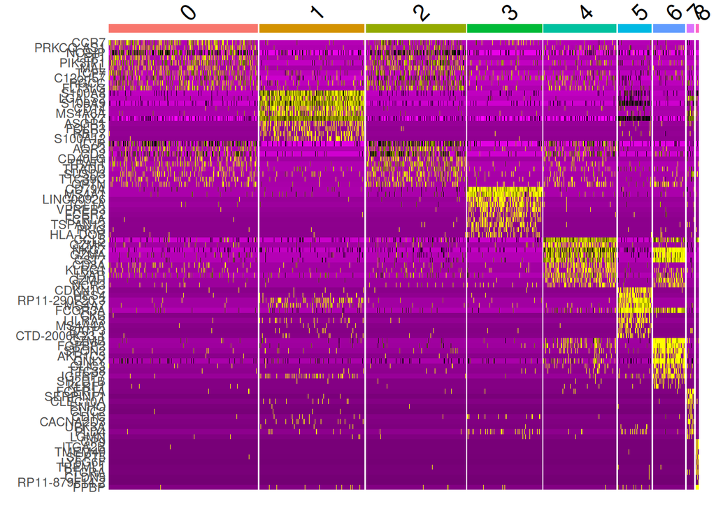

```r
# 这里用的Seurat版本是4.0.1
# 如果你用的是Seurat 3.X.X以下版本，需要把本文档所有的avg_log2FC替换为avg_logFC，或者运行下面这行
# The Seurat version used here is 4.0.1
# If you are using Seurat 3.X.X or earlier, you will need to replace all the avg_log2FC in this document with avg_logFC, or run the following line
#pbmc.markers$avg_log2FC <- pbmc.markers$avg_logFC

# 查看top10 marker gene
# View the top 10 marker gene
top10 <- pbmc.markers %>% group_by(cluster) %>% top_n(n = 10, wt = avg_log2FC)
DoHeatmap(pbmc, features = top10$gene) + NoLegend()
```

## 8 鉴定细胞类型 Identify cell types

如果只是为了复现文章中的图，可以不鉴定细胞类型，以下部分可不run，根据结合每个cluster的marker基因和生物学知识确定细胞类型。

为了接近真实情况并结合示例数据，这里不将细胞类型划分的这么详细，进行以下更改

If you don’t need to identify the cell types just to reproduce the diagram in the article, the following section can be done without running and determine the cell type based on the knowledge of the marker genes and biology that binds each cluster.

In order to get close to the real situation and combine the example data, the cell types are not divided into such details here, and the following changes are made

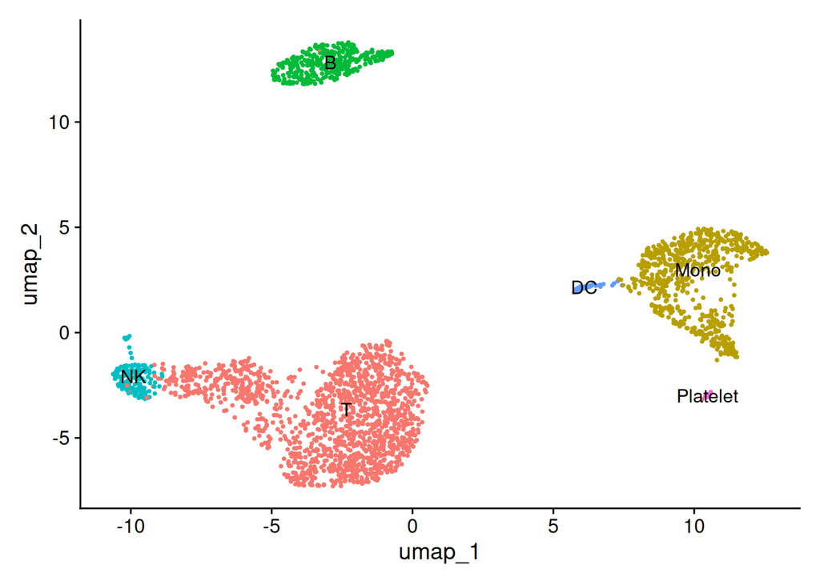

```r
# 给每个cluster标注细胞类型
# Label each cluster with cell types
new.cluster.ids <- c("T", "Mono", "T", "B", "T", "Mono", "NK", "DC", "Platelet")
names(new.cluster.ids) <- levels(pbmc)
pbmc <- RenameIdents(pbmc, new.cluster.ids)
# 添加细胞类型至meta data
# Add cell types to meta data
pbmc@meta.data$celltype <- pbmc@active.ident
DimPlot(pbmc, reduction = "umap", label = TRUE, pt.size = 0.5) + NoLegend()
```

```r
pA2 <-  pA2 <- DimPlot(pbmc, reduction = "umap", label = F,group.by = "celltype")
ggsave("plotA_1_UMAP_celltype.pdf", plot = pA2, width = 6, height = 6)

# 自定义颜色
# Custom colors
colourCount <- length(unique(pbmc@meta.data$celltype))
getPalette <- colorRampPalette(brewer.pal(8, "Dark2"))
celltype_colors <- getPalette(colourCount)
pA2 <- pA2 <- DimPlot(pbmc, reduction = "umap", label = F,group.by = "celltype",cols = celltype_colors)
ggsave("plotA_1_UMAP_celltype_color.pdf", plot = pA2, width = 6,height = 6)

## 拼图
## Puzzles
pA_all <- pA1 + pA2 + plot_layout(ncol = 2, widths = c(1, 1))
## 保存
## Save
ggsave("plotA_all.pdf", plot = pA_all, width = 12, height = 6)

celltype <- c("T","Mono","B","NK","DC","Platelet")
pbmc@meta.data$celltype <- factor(pbmc@meta.data$celltype, celltype)
#saveRDS(pbmc, "pbmc_test_final.rds")
```

## 9 设置cutoff，定义显著/非显著的上/下调marker gene

Set cutoff to define significant/non-significant up/down marker gene

```r
# 查看每个cluster的marker gene
# View the marker gene of each cluster
pbmc.markers %>% group_by(cluster) %>% top_n(n = 2, # 前两个 # The first two
                                             wt = avg_log2FC)
```

```
## # A tibble: 18 × 7
## # Groups:   cluster [9]
##        p_val avg_log2FC pct.1 pct.2 p_val_adj cluster gene
##        <dbl>      <dbl> <dbl> <dbl>     <dbl> <fct>   <chr>
##  1 1.10e- 81       2.35 0.432 0.111 1.51e- 77 0       CCR7
##  2 2.53e- 48       2.12 0.336 0.108 3.46e- 44 0       PRKCQ-AS1
##  3 5.80e-139       7.15 0.297 0.005 7.96e-135 1       FOLR3
##  4 1.39e-123       6.77 0.275 0.006 1.90e-119 1       S100A12
##  5 4.78e- 57       2.06 0.42  0.113 6.56e- 53 2       AQP3
##  6 4.21e- 46       2.14 0.289 0.064 5.77e- 42 2       CD40LG
##  7 2.40e-276       7.26 0.562 0.009 3.29e-272 3       LINC00926
##  8 6.96e-238       6.96 0.484 0.007 9.55e-234 3       VPREB3
##  9 4.29e-201       4.92 0.599 0.049 5.88e-197 4       GZMK
## 10 2.45e- 81       3.61 0.381 0.059 3.35e- 77 4       GZMH
## 11 2.77e-222       5.49 0.516 0.009 3.79e-218 5       CDKN1C
## 12 1.77e-175       5.95 0.377 0.005 2.43e-171 5       CKB
## 13 1.09e-259       5.88 0.966 0.072 1.49e-255 6       GZMB
## 14 1.05e-190       6.25 0.493 0.013 1.44e-186 6       AKR1C3
## 15 1.43e-267       8.04 0.833 0.009 1.96e-263 7       FCER1A
## 16 3.99e-213       8.15 0.472 0.002 5.48e-209 7       SERPINF1
## 17 3.89e-314      14.2  0.533 0     5.33e-310 8       LY6G6F
## 18 6.60e-197      13.8  0.333 0     9.04e-193 8       RP11-879F14.2
```

```r
# 查看每个cluster的marker基因数量
# Check the number of marker genes in each cluster
table(pbmc.markers$cluster)
```

```
##
##   0   1   2   3   4   5   6   7   8
## 536 713 383 476 328 891 662 929 430
```

```r
# 根据自己计算的marker基因数量确定log2FC的阈值，这里先定为0.5
# Determine the threshold of log2FC based on the number of marker genes calculated by yourself, here it is set to 0.5 first
pbmc.markers <- subset(pbmc.markers, p_val_adj < 0.05 & abs(avg_log2FC) > 0.5)
pbmc.markers$threshold <- as.factor(ifelse(pbmc.markers$avg_log2FC > 0 , 'Up', 'Down'))
dim(pbmc.markers)
```

```
## [1] 3047    8
```

```r
table(pbmc.markers$threshold)
```

```
##
## Down   Up
## 1089 1958
```

```r
pbmc.markers$adj_p_signi <- as.factor(ifelse(pbmc.markers$p_val_adj < 0.01 , 'Highly', 'Lowly'))
pbmc.markers$thr_signi <- paste0(pbmc.markers$threshold, "_", pbmc.markers$adj_p_signi)
pbmc.markers$cluster %<>% as.vector(.) %>% as.numeric(.)

# 保存到文件
# Save to file
write.csv(pbmc.markers, "output_pbmc.markers.csv", quote = F)
```

## 10 自定义显示想要展示的基因名 Customize the display of the gene name you want to display

这里挑选log2FC为top5的基因进行展示

Here, log2FC is selected as the top 5 genes for display

```r
top_up_label <- pbmc.markers %>%
  subset(., threshold%in%"Up") %>%
  group_by(cluster) %>%
  top_n(n = 5, wt = avg_log2FC) %>%
  as.data.frame()

top_down_label <- pbmc.markers %>%
  subset(., threshold %in% "Down") %>%
  group_by(cluster) %>%
  top_n(n = -5, wt = avg_log2FC) %>%
  as.data.frame()

top_label <- rbind(top_up_label,top_down_label)
top_label$thr_signi %<>%
  factor(., levels = c("Up_Highly","Down_Highly","Up_Lowly","Down_Lowly"))

# 保存到文件，便于小白套用格式
# Save to a file for easy formatting
#write.csv(top_label, "easy_input_label.csv", quote = F)
```

也可以基于output_pbmc.markers.csv文件，手动挑选出想要标注名字的基因，例如标注参与某一通路的基因，然后将文件命名为easy_input_label.csv

You can also manually pick out the genes you want to name based on output_pbmc.markers.csv files, such as genes involved in a pathway, and then name the file easy_input_label.csv

## 11 开始画图 Start drawing

```r
# 读取修改后的要标注的基因名文件
# Read the modified gene name file to be labeled
#top_label <- read.csv("easy_input_label.csv")

### 准备绘制暗灰色背景所需数据
### Prepare the data needed to draw a dark gray background
background_position <- pbmc.markers %>%
  group_by(cluster) %>%
  summarise(Min = min(avg_log2FC) - 0.2, Max = max(avg_log2FC) + 0.2) %>%
  as.data.frame()
background_position$cluster %<>% as.vector(.) %>% as.numeric(.)
background_position$start <- background_position$cluster - 0.4
background_position$end <- background_position$cluster + 0.4

### 准备绘制中间区域cluster彩色bar所需数据
### Prepare the data required to plot the cluster color bar in the middle region
cluster_bar_position <- background_position
cluster_bar_position$start <- cluster_bar_position$cluster - 0.5
cluster_bar_position$end <- cluster_bar_position$cluster + 0.5
cluster_bar_position$cluster %<>%
  factor(., levels = c(0:max(as.vector(.))))

## 设置填充颜色
## Set the fill color
cols_thr_signi <- c("Up_Highly" = "#d7301f",
                    "Down_Highly" = "#225ea8",
                    "Up_Lowly" = "black",
                    "Down_Lowly" = "black")
cols_cluster <- c("0" = "#35978f",
                  "1" = "#8dd3c7",
                  "2" = "#ffffb3",
                  "3" = "#bebada",
                  "4" = "#fb8072",
                  "5" = "#80b1d3",
                  "6" = "#fdb462",
                  "7" = "#b3de69",
                  "8" = "#fccde5")

p <- ggplot() +
  geom_rect(data = background_position, aes(xmin = start, xmax = end, ymin = Min,
                                          ymax = Max),
            fill = "#525252", alpha = 0.1) + ###添加灰色背景色 ### Add a gray background color
  geom_jitter(data = pbmc.markers, aes(x = cluster, y = avg_log2FC, colour = thr_signi),
              size = 1,position = position_jitter(seed = 1)) +
  scale_color_manual(values = cols_thr_signi) +
  scale_x_continuous(limits = c(-0.5, max(pbmc.markers$cluster) + 0.5),
                     breaks = seq(0, max(pbmc.markers$cluster), 1),
                     label = seq(0, max(pbmc.markers$cluster),1)) + #修改坐标轴显示刻度 # Modify the axis display scale

  # 根据top_label标注基因名
  # Label the gene name according to the top_label
  geom_text_repel(data = top_label, aes(x = cluster, y = avg_log2FC, label = gene),
                  position = position_jitter(seed = 1), show.legend = F, size = 2.5,
                  box.padding = unit(0, "lines")) +

  geom_rect(data = cluster_bar_position, aes(xmin = start, xmax = end, ymin = -0.4,
                                           ymax = 0.4, fill = cluster), color = "black", alpha = 1, show.legend = F) +
  scale_fill_manual(values = cols_cluster) +
  labs(x = "Cluster", y = "average log2FC") +
  theme_bw()

plot1 <- p + theme(panel.grid.minor = element_blank(), ##去除网格线 ## Remove grid lines
                   panel.grid.major = element_blank(),
                   axis.text.y = element_text(colour = 'black', size = 14),
                   axis.text.x = element_text(colour = 'black', size = 14, vjust = 46), #调整x轴坐标,vjust的值按照最终结果稍加调整 # Adjust the x-axis coordinates, and the value of vjust will be slightly adjusted according to the final result
                   panel.border = element_blank(), ## 去掉坐标轴 ## Remove the axes
                   axis.ticks.x = element_blank(), ## 去掉的坐标刻度线 ## Removed coordinate tick marks
                   axis.line.y = element_line(colour = "black")) #添加y轴坐标轴 # Add the y-axis
ggsave(filename = "Marker_gene_pointplot.pdf", plot = plot1, width = 9, height = 6)
```

[figure not shown]